# modelo_estudo

### Sumário das variáveis projeto

- **1. id_reserva:** Identificador único de cada reserva;
- **2. numero_adultos:** Número de adultos no quarto;
- **3. numero_criancas:** Número de crianças no quarto;
- **4. noites_fim_de_semana:** Número de noites de fim de semana (sábado ou domingo) em que o hóspede ficou ou reservou estadia no hotel;
- **5. noites_dias_semana:** Número de noites da semana (segunda a sexta) em que o hóspede ficou ou reservou estadia no hotel;
- **6. tipo_plano_refeicao:** Tipo de plano de refeição reservado pelo cliente;
- **7. vaga_estacionamento_requerida:** Indica se o cliente precisa de uma vaga de estacionamento (0 para Não, 1 para Sim);
- **8. tipo_quarto_reservado:** Tipo de quarto reservado pelo cliente (os valores são codificados);
- **9. antecedencia_reserva:** Número de dias entre a data da reserva e a data de chegada;
- **10. ano_chegada:** Ano da data de chegada;
- **11. mes_chegada:** Mês da data de chegada;
- **12. dia_chegada:** Dia do mês da data de chegada;
- **13. segmento_mercado:** Designação do segmento de mercado;
- **14. cliente_recorrente:** Indica se o cliente é um hóspede recorrente (0 para Não, 1 para Sim);
- **15. num_cancelamentos_anteriores:** Número de reservas anteriores que foram canceladas pelo cliente antes da reserva atual;
- **16. num_reservas_anteriores_sem_cancelar:** Número de reservas anteriores não canceladas pelo cliente antes da reserva atual;
- **17. preco_medio_diaria:** Preço médio por dia da reserva (em euros); os preços dos quartos são dinâmicos;
- **18. num_solicitacoes_especiais:** Número total de solicitações especiais feitas pelo cliente (ex.: andar alto, vista do quarto, etc.); e
- **19. status_reserva:** Sinalizador que indica se a reserva foi cancelada ou não.

### 1. Importando bibliotecas

```python
import pandas as pd  # Manipulação de dados com DataFrames
import numpy as np  # Operações matemáticas e manipulação de arrays

import matplotlib.pyplot as plt  # Visualizações gráficas
import seaborn as sns  # Visualizações estatísticas

from sklearn.model_selection import train_test_split  # Separação dos dados em treino e teste

from sklearn.preprocessing import MinMaxScaler  # Padroniza os dados para um intervalo entre 0 e 1

from imblearn.combine import SMOTEENN # Balanceia - oversampling - aumento
from imblearn.under_sampling import RandomUnderSampler # Balanceia - undersampling - diminui

from sklearn.model_selection import StratifiedKFold, cross_val_score

from sklearn.tree import DecisionTreeClassifier
from sklearn.ensemble import RandomForestClassifier
from sklearn.ensemble import ExtraTreesClassifier
from sklearn.ensemble import GradientBoostingClassifier
from sklearn.linear_model import LogisticRegression
from sklearn.neural_network import MLPClassifier
from xgboost import XGBClassifier
from lightgbm import LGBMClassifier

from sklearn.metrics import accuracy_score  # Métrica de acurácia
from sklearn.metrics import confusion_matrix, ConfusionMatrixDisplay  # Matriz de confusão e visualização
from sklearn.metrics import roc_curve  # Curva ROC
from sklearn.metrics import roc_auc_score  # AUC da curva ROC
from sklearn.metrics import classification_report  # Relatório com precisão, recall, f1-score, etc.
```

### 2. Guardando funções

```python
# def - IV que checa toda a base e não checa individualmente as categorias
def classify_iv(iv):
    if iv < 0.02:
        return 'Muito baixo'
    elif iv < 0.1:
        return 'Baixo'
    elif iv < 0.3:
        return 'Médio'
    elif iv < 0.5:
        return 'Alto'
    else:
        return 'Muito alto / suspeito'

def calculate_iv(df, target, bins=10, show_woe=False):
    iv_list = []

    for col in df.columns:
        if col == target:
            continue

        tmp = pd.DataFrame()
        if pd.api.types.is_numeric_dtype(df[col]):
            # Binning automático para variáveis numéricas
            tmp['bin'] = pd.qcut(df[col].rank(method='first'), q=min(bins, df[col].nunique()), duplicates='drop')
        else:
            tmp['bin'] = df[col]

        tmp[target] = df[target]

        grouped = tmp.groupby('bin', observed=False)[target].agg(['count', 'sum'])
        grouped.columns = ['total', 'bad']
        grouped['good'] = grouped['total'] - grouped['bad']

        total_good = grouped['good'].sum()
        total_bad = grouped['bad'].sum()
        grouped['dist_good'] = grouped['good'] / total_good
        grouped['dist_bad'] = grouped['bad'] / total_bad

        # Evita log(0)
        grouped['dist_good'] = grouped['dist_good'].replace(0, 0.0001)
        grouped['dist_bad'] = grouped['dist_bad'].replace(0, 0.0001)

        # WOE e IV
        grouped['WOE'] = np.log(grouped['dist_good'] / grouped['dist_bad'])
        grouped['IV'] = (grouped['dist_good'] - grouped['dist_bad']) * grouped['WOE']
        iv = grouped['IV'].sum()

        if show_woe:
            print(f"\nWOE para {col}")
            print(grouped[['WOE', 'IV']])

        iv_list.append({
            'variavel': col,
            'IV': iv,
            'tipo': 'numérica' if pd.api.types.is_numeric_dtype(df[col]) else 'categórica',
            'classificacao_IV': classify_iv(iv)
        })

    iv_df = pd.DataFrame(iv_list).sort_values(by='IV', ascending=False).reset_index(drop=True)
    return iv_df
```

```python
# def - WOE que checa a variável individualmente
def analisar_variavel_com_woe(
    df: pd.DataFrame,
    variavel: str,
    target: str,
    bins: int = 5,
    cortes: list = None
) -> pd.DataFrame:
    """
    Analisa uma variável calculando o WoE com 3 modos de binning:
    1. Histograma (padrão): Forneça `bins=N`. Cria N bins de largura igual.
    2. Manual: Forneça uma lista de `cortes=[...]`. Cria bins com os cortes exatos.
    3. Categórico: Se a variável não for numérica, agrupa por categorias únicas.
    """
    temp_df = df[[variavel, target]].copy()
    total_dataset = len(temp_df)
    total_0 = (temp_df[target] == 0).sum()
    total_1 = (temp_df[target] == 1).sum()

    if total_0 == 0: total_0 = 1
    if total_1 == 0: total_1 = 1

    df_non_nan = temp_df.dropna(subset=[variavel])
    df_nan = temp_df[temp_df[variavel].isnull()]
    nome_coluna = variavel + '_bin'

    # --- LÓGICA DE BINNING ATUALIZADA ---
    if cortes:
        # Modo 2: Binning Manual com cortes exatos
        df_non_nan['categoria'] = pd.cut(df_non_nan[variavel], bins=cortes, right=True)
    else:
        # Verifica se a variável é numérica e pode ser "binada"
        if pd.api.types.is_numeric_dtype(df[variavel]) and df_non_nan[variavel].nunique() > bins:
            # Modo 1: Binning tipo Histograma (largura igual)
            df_non_nan['categoria'] = pd.cut(df_non_nan[variavel], bins=bins, duplicates='drop') # <<< MUDANÇA PRINCIPAL AQUI
        else:
            # Modo 3: Agrupamento por categorias únicas
            df_non_nan['categoria'] = df_non_nan[variavel]
            nome_coluna = variavel
    # ------------------------------------

    tabela = df_non_nan.groupby('categoria', observed=False)[target].agg(['sum', 'count']).reset_index()
    tabela.columns = [nome_coluna, 'count_1', 'total']

    if not df_nan.empty:
        nan_row = pd.DataFrame({
            nome_coluna: ['Missing'],
            'count_1': [df_nan[target].sum()],
            'total': [len(df_nan)]
        })
        tabela = pd.concat([tabela, nan_row], ignore_index=True)

    # O resto do cálculo do WoE permanece o mesmo
    tabela['count_0'] = tabela['total'] - tabela['count_1']
    tabela['representatividade'] = tabela['total'] / total_dataset
    tabela['perc_1_na_categoria'] = tabela['count_1'] / tabela['total']
    tabela['perc_0_dist'] = tabela['count_0'] / total_0
    tabela['perc_1_dist'] = tabela['count_1'] / total_1
    tabela['perc_0_dist'] = tabela['perc_0_dist'].replace(0, 0.00001)
    tabela['perc_1_dist'] = tabela['perc_1_dist'].replace(0, 0.00001)
    tabela['WoE'] = np.log(tabela['perc_0_dist'] / tabela['perc_1_dist'])

    output_cols = [nome_coluna, 'WoE', 'representatividade', 'total', 'count_0', 'count_1', 'perc_1_na_categoria']
    return tabela[output_cols].sort_values(by='WoE').reset_index(drop=True)
```

```python
def correlacao(df, tamanho=(14, 10), mascara=True, title='Mapa de Correlação'):
    """
    Plota um gráfico de correlação altamente visual e estilizado.

    Parâmetros:
    - df: DataFrame (somente variáveis numéricas serão consideradas)
    - tamanho: tupla (largura, altura)
    - mascara: se True, oculta metade inferior para foco visual
    - title: título do gráfico
    """
    # Seleciona apenas colunas numéricas
    corr = df.select_dtypes(include=[np.number]).corr()

    # Cria máscara para metade inferior, se desejado
    mask = np.tril(np.ones_like(corr, dtype=bool)) if mascara else None

    # Define estilo
    sns.set_theme(style="white") # <--- MUDANÇA 1: Tema mais limpo

    # Cria figura
    fig = plt.figure(figsize=tamanho)
    heatmap = sns.heatmap(
        corr,
        mask=mask,
        annot=True,
        fmt=".2f",
        cmap='vlag', # <--- MUDANÇA 2: Paleta de cores aprimorada
        vmin=-1, vmax=1,
        linewidths=0.5,
        linecolor='lightgray',
        square=True,
        cbar_kws={"shrink": 0.85, "label": "Correlação"},
        annot_kws={"size": 12, "color": "black"}
    )

    # Ajusta visual
    plt.title(title, fontsize=18, weight='bold')
    plt.xticks(rotation=45, ha='right', fontsize=11)
    plt.yticks(rotation=0, fontsize=11)
    plt.tight_layout()
    plt.show()

    # Libera memória
    plt.close(fig)
```

```python
def tabela_frequencia(serie, nome_coluna='Variável'):
    """
    Gera uma tabela de frequência com contagem absoluta, relativa (%) e acumulada (%),
    ordenada da categoria mais frequente para a menos frequente.

    Parâmetros:
    - serie: pd.Series (coluna do DataFrame)
    - nome_coluna: nome opcional da variável analisada

    Retorna:
    - DataFrame com as frequências
    """
    freq_abs = serie.value_counts(dropna=False)
    freq_rel = freq_abs / freq_abs.sum()
    freq_acum = freq_rel.cumsum()

    tabela = pd.DataFrame({
        nome_coluna: freq_abs.index.astype(str),
        'Frequência Absoluta': freq_abs.values,
        'Frequência Relativa (%)': (freq_rel * 100).round(2),
        'Frequência Acumulada (%)': (freq_acum * 100).round(2)
    })

    return tabela.reset_index(drop=True)
```

```python
def barras(serie, xlabel='Frequência', ylabel='Categorias'):
    """
    Gera um gráfico de barras horizontais com valores absolutos e percentuais.

    Parâmetros:
    - serie: pd.Series com dados categóricos
    - xlabel: rótulo do eixo x
    - ylabel: rótulo do eixo y
    """
    contagem = serie.value_counts(dropna=False)
    percentual = contagem / contagem.sum() * 100
    categorias = contagem.index.astype(str)

    df_plot = pd.DataFrame({
        'Categoria': categorias,
        'Frequência': contagem.values,
        'Porcentagem': percentual.values
    })

    fig, ax = plt.subplots(figsize=(15, 5))
    sns.barplot(
        data=df_plot,
        y='Categoria',
        x='Frequência',
        hue='Categoria',  # <- corrigido
        palette='pastel',
        dodge=False,
        legend=False,
        ax=ax
    )

    for i, (freq, pct) in enumerate(zip(df_plot['Frequência'], df_plot['Porcentagem'])):
        ax.text(freq + df_plot['Frequência'].max() * 0.01, i, f'{freq} ({pct:.1f}%)', va='center', fontsize=10)

    ax.set_xlabel(xlabel, fontsize=12)
    ax.set_ylabel(ylabel, fontsize=12)
    ax.set_title(f'Gráfico de Barras - {serie.name}', fontsize=14, fontweight='bold')
    sns.despine(left=True, bottom=True)
    plt.tight_layout()
    plt.show()

    plt.close(fig)
```

```python
def boxplot(serie, titulo=None, xlabel='Valores', ylabel=''):
    """
    Gera dois boxplots horizontais: um com todos os dados (com outliers)
    e outro com dados sem outliers (em escalas independentes).

    Exibe os valores de média e mediana no canto superior direito dos gráficos.

    Parâmetros:
    - serie: pd.Series com dados numéricos
    - titulo: título do gráfico (opcional). Se None, usa o nome da série.
    """
    import matplotlib.pyplot as plt
    import seaborn as sns

    # Definindo título automático
    if titulo is None:
        titulo = str(serie.name) if serie.name else 'Boxplots em Planos Diferentes'

    # Estatísticas gerais
    media_total = serie.mean()
    mediana_total = serie.median()

    # Cálculo dos limites de outlier
    Q1 = serie.quantile(0.25)
    Q3 = serie.quantile(0.75)
    IQR = Q3 - Q1
    limite_inferior = Q1 - 1.5 * IQR
    limite_superior = Q3 + 1.5 * IQR

    # Dados
    total = len(serie)
    dados_sem_outliers = serie[(serie >= limite_inferior) & (serie <= limite_superior)]
    media_sem_outliers = dados_sem_outliers.mean()
    mediana_sem_outliers = dados_sem_outliers.median()
    total_outliers = total - len(dados_sem_outliers)

    # Plotando
    fig, axes = plt.subplots(1, 2, figsize=(14, 5))

    # Boxplot sem outliers (média e mediana sem outliers)
    sns.boxplot(x=dados_sem_outliers, color='skyblue', ax=axes[0])
    axes[0].set_title('Sem Outliers')
    axes[0].set_xlabel(xlabel)
    axes[0].set_ylabel(ylabel)
    axes[0].text(
        0.98, 0.95,
        f'Média (sem outliers): {media_sem_outliers:.2f}\nMediana (sem outliers): {mediana_sem_outliers:.2f}',
        transform=axes[0].transAxes,
        ha='right', va='top', fontsize=12, color='dimgray'
    )
    axes[0].text(
        0.98, 0.05,
        f'Total (sem outliers): {len(dados_sem_outliers)}\nOutliers detectados: {total_outliers}',
        transform=axes[0].transAxes,
        ha='right', va='bottom', fontsize=10, color='dimgray'
    )

    # Boxplot com outliers (média e mediana com todos os dados)
    sns.boxplot(x=serie, color='salmon', ax=axes[1])
    axes[1].set_title('Com Outliers')
    axes[1].set_xlabel(xlabel)
    axes[1].set_ylabel(ylabel)
    axes[1].text(
        0.98, 0.95,
        f'Média (com outliers): {media_total:.2f}\nMediana (com outliers): {mediana_total:.2f}',
        transform=axes[1].transAxes,
        ha='right', va='top', fontsize=12, color='dimgray'
    )
    axes[1].text(
        0.98, 0.05,
        f'Total: {total}',
        transform=axes[1].transAxes,
        ha='right', va='bottom', fontsize=10, color='dimgray'
    )

    # Título e legenda
    plt.suptitle(titulo, fontsize=16)
    plt.tight_layout()
    plt.subplots_adjust(top=0.85)
    plt.show()

    # Libera memória
    plt.close(fig)
```

```python
def histograma(serie, titulo=None, xlabel='Valores', ylabel='Frequência', bins=10):
    """
    Gera um histograma com faixa de valores nos rótulos do eixo x,
    curva de densidade (KDE) e linhas de média e mediana.

    Parâmetros:
    - serie: pd.Series com dados numéricos
    - titulo: título do gráfico (opcional). Se None, usa o nome da série.
    - xlabel: rótulo do eixo x
    - ylabel: rótulo do eixo y
    - bins: número de compartimentos (int) ou sequência de intervalos
    """
    if titulo is None:
        titulo = str(serie.name) if serie.name else 'Histograma com Densidade'

    # Calcular média e mediana
    media = serie.mean()
    mediana = serie.median()

    # Definir bordas dos bins
    dados = serie.dropna()
    if isinstance(bins, int):
        edges = np.histogram_bin_edges(dados, bins=bins)
    else:
        edges = np.array(bins)

    # Criar figura e eixo
    fig, ax = plt.subplots(figsize=(12, 4))

    # Plotar histograma com bins definidos
    sns.histplot(dados, bins=edges, kde=True, color='skyblue', edgecolor='gray', ax=ax)

    # Adicionar linhas de média e mediana
    ax.axvline(media, color='red', linestyle='--', linewidth=2, label=f'Média: {media:.2f}')
    ax.axvline(mediana, color='green', linestyle='--', linewidth=2, label=f'Mediana: {mediana:.2f}')

    # Configurar rótulos personalizados para cada faixa
    tick_positions = (edges[:-1] + edges[1:]) / 2
    tick_labels = [f"{int(edges[i])}-{int(edges[i+1])}" for i in range(len(edges)-1)]
    ax.set_xticks(tick_positions)
    ax.set_xticklabels(tick_labels, rotation=45, ha='right')

    # Definir títulos e legendas
    ax.set_title(titulo, fontsize=14)
    ax.set_xlabel(xlabel, fontsize=12)
    ax.set_ylabel(ylabel, fontsize=12)
    ax.legend(loc='upper right')

    plt.tight_layout()
    plt.show()
    plt.close(fig)
```

```python
# def - Tratar outliers com winsonização

def aplicar_winsorizacao(df, colunas, limites=(0.08, 0.08)):
    """
    Aplica winsorização às colunas selecionadas de um DataFrame usando métodos do pandas.
    Esta função lida corretamente com valores ausentes (NaN).

    Parâmetros:
    - df: DataFrame original.
    - colunas: lista de colunas numéricas a serem winsorizadas.
    - limites: tupla (inferior, superior) com os percentis de corte.
      Ex: (0.08, 0.08) corta os 8% inferiores e os 8% superiores.

    Retorna:
    - Novo DataFrame com as colunas especificadas winsorizadas.
    """
    df_wins = df.copy()

    # Extrai os limites inferior e superior da tupla
    limite_inferior_percentil = limites[0]
    limite_superior_percentil = 1 - limites[1] # O quantil superior é 1 - o limite

    for col in colunas:
        # Pula a coluna se não for numérica para evitar erros
        if pd.api.types.is_numeric_dtype(df_wins[col]):
            # 1. Calcula os valores dos quantis (limites de corte)
            # O método .quantile() do pandas ignora NaNs por padrão
            limite_inf_valor = df_wins[col].quantile(limite_inferior_percentil)
            limite_sup_valor = df_wins[col].quantile(limite_superior_percentil)

            # 2. Aplica o "corte" (clip) nos valores da coluna
            # Valores menores que o limite inferior se tornam o limite inferior.
            # Valores maiores que o limite superior se tornam o limite superior.
            df_wins[col] = df_wins[col].clip(
                lower=limite_inf_valor,
                upper=limite_sup_valor
            )

    return df_wins
```

```python
def plotar_analise_numerica_vs_target(df, var_numerica, var_target):
    """
    Cria e exibe dois gráficos lado a lado para analisar uma variável numérica
    em relação a uma variável-alvo binária.

    Args:
        df (pd.DataFrame): O DataFrame contendo os dados.
        var_numerica (str): O nome da coluna com a variável numérica a ser analisada.
        var_target (str): O nome da coluna com a variável-alvo binária (0s e 1s).
    """
    # Configurando o estilo e o tamanho da figura
    sns.set_style("whitegrid")
    plt.figure(figsize=(18, 6))

    # --- Gráfico 1: Histograma de Densidade (KDE Plot)
    plt.subplot(1, 2, 1)
    sns.kdeplot(data=df, x=var_numerica, hue=var_target, fill=True,
                common_norm=False, palette='viridis')

    # Títulos e rótulos dinâmicos baseados nos parâmetros
    plt.title(f'Distribuição de "{var_numerica}" por "{var_target}"', fontsize=14)
    plt.xlabel(var_numerica)
    plt.ylabel('Densidade')

    # --- Gráfico 2: Box Plot
    plt.subplot(1, 2, 2)
    sns.boxplot(data=df, x=var_target, y=var_numerica, hue=var_target,
                palette='viridis', legend=False)

    # Títulos e rótulos dinâmicos
    plt.title(f'Comparação de "{var_numerica}" por "{var_target}"', fontsize=14)
    plt.xlabel(f'{var_target} (0 = Não, 1 = Sim)') # Rótulo genérico
    plt.ylabel(var_numerica)

    # Ajusta o layout e exibe os gráficos
    plt.tight_layout()
    plt.show()
```

```python
# def - Relatório modelos classificação
def gerar_relatorio_classificacao(nome_modelo, modelo, X_train, y_train, X_test, y_test,
                                  threshold=None, detalhado=True):
    """
    Gera um relatório de classificação para treino e teste.
    Permite especificar um threshold customizado e escolher entre relatório detalhado ou resumido.

    Args:
        nome_modelo (str): Nome do modelo para exibição.
        modelo (estimator): O objeto do modelo já treinado.
        X_train, y_train: Dados e rótulos de treino.
        X_test, y_test: Dados e rótulos de teste.
        threshold (float, optional): Limiar para classificação. Se None, usa o .predict() padrão.
                                     Default é None.
        detalhado (bool, optional): Se True, imprime o relatório completo.
                                    Se False, imprime o relatório resumido. Default é True.
    """
    # Define o cabeçalho do relatório
    if threshold is not None:
        header = f" {nome_modelo} (Threshold = {threshold:.2f}) "
    else:
        header = f" {nome_modelo} (Threshold Padrão) "
    print(header.center(60, "="))

    # --- Lógica de Predição ---
    if threshold is not None:
        # Usa predict_proba se um threshold for especificado
        y_pred_train = (modelo.predict_proba(X_train)[:, 1] >= threshold).astype(int)
        y_pred_test = (modelo.predict_proba(X_test)[:, 1] >= threshold).astype(int)
    else:
        # Usa predict padrão se nenhum threshold for especificado
        y_pred_train = modelo.predict(X_train)
        y_pred_test = modelo.predict(X_test)

    # --- Lógica de Impressão do Relatório ---
    # TREINO
    print("\nTreino ----------------------------------------------------")
    if detalhado:
        print(classification_report(y_train, y_pred_train, digits=2, zero_division=0))
    else:
        relatorio = classification_report(y_train, y_pred_train, output_dict=True, zero_division=0)
        print("Classe 0 - Precisão: {:.0f}%, Recall: {:.0f}%".format(
            relatorio['0']['precision'] * 100, relatorio['0']['recall'] * 100))
        print("Classe 1 - Precisão: {:.0f}%, Recall: {:.0f}%".format(
            relatorio['1']['precision'] * 100, relatorio['1']['recall'] * 100))

    # TESTE
    print("Teste -----------------------------------------------------")
    if detalhado:
        print(classification_report(y_test, y_pred_test, digits=2, zero_division=0))
    else:
        relatorio = classification_report(y_test, y_pred_test, output_dict=True, zero_division=0)
        print("Classe 0 - Precisão: {:.0f}%, Recall: {:.0f}%".format(
            relatorio['0']['precision'] * 100, relatorio['0']['recall'] * 100))
        print("Classe 1 - Precisão: {:.0f}%, Recall: {:.0f}%".format(
            relatorio['1']['precision'] * 100, relatorio['1']['recall'] * 100))

    print("=" * 60 + "\n")
```

### 3. Importando base de dados

```python
df = pd.read_csv('Hotel Reservations.csv')
```

### 4. Tratamento e verificação prévia dos dados

- **Nomes das variáveis foram alterados?:** Sim. Para português-BR que torna mais acessível a interpretação geral.
- **Número de colunas:** 19 colunas.
- **Número de linhas:** Originalmente, 36275 linhas.
- **Valores nulos por coluna:** 0 valores nulos em todas as colunas.
- **Categorias duplicadas com nomes diferentes:** 0 categorias iguais, que representam o mesmo objeto, com nomes diferentes.
- **Valores mínimos/máximos/médias:** Durante a verificação da integridade dos dados, todas as colunas se mostraram consistentes, com exceção numero_adultos.
  - **numero_adultos:** Foram encontrados 121 registros com 0 adultos que é algo impossível visto que não pode estar apenas uma criança sozinha. Logo, deve ser um erro de imputação mas, de toda sorte, não temos acesso as informações. Logo, optamos por isolar esses registros.
  - **preco_medio_quarto:** Foram identificadas 598 linhas com preco_medio_quarto inferior a 10 euros. Devido à impossibilidade de validar a origem destes dados, optou-se por isolar tais registros para não distorcer a análise."

```python
df.rename(columns={
                    'Booking_ID': 'id_reserva',
                    'no_of_adults': 'numero_adultos',
                    'no_of_children': 'numero_criancas',
                    'no_of_weekend_nights': 'noites_fim_de_semana',
                    'no_of_week_nights': 'noites_semana',
                    'type_of_meal_plan': 'tipo_plano_refeicao',
                    'required_car_parking_space': 'vaga_estacionamento_requerida',
                    'room_type_reserved': 'tipo_quarto_reservado',
                    'lead_time': 'dias_antecedencia',
                    'arrival_year': 'ano_chegada',
                    'arrival_month': 'mes_chegada',
                    'arrival_date': 'dia_chegada',
                    'market_segment_type': 'segmento_mercado',
                    'repeated_guest': 'cliente_recorrente',
                    'no_of_previous_cancellations': 'cancelamentos_anteriores',
                    'no_of_previous_bookings_not_canceled': 'reservas_nao_canceladas_anteriormente',
                    'avg_price_per_room': 'preco_medio_quarto',
                    'no_of_special_requests': 'numero_solicitacoes_especiais',
                    'booking_status': 'status_reserva'}, inplace=True)
```

```python
df.describe()
```

|  | numero_adultos | numero_criancas | noites_fim_de_semana | noites_semana | vaga_estacionamento_requerida | dias_antecedencia | ano_chegada | mes_chegada | dia_chegada | cliente_recorrente | cancelamentos_anteriores | reservas_nao_canceladas_anteriormente | preco_medio_quarto | numero_solicitacoes_especiais |
| --- | --- | --- | --- | --- | --- | --- | --- | --- | --- | --- | --- | --- | --- | --- |
| count | 36275.000000 | 36275.000000 | 36275.000000 | 36275.000000 | 36275.000000 | 36275.000000 | 36275.000000 | 36275.000000 | 36275.000000 | 36275.000000 | 36275.000000 | 36275.000000 | 36275.000000 | 36275.000000 |
| mean | 1.844962 | 0.105279 | 0.810724 | 2.204300 | 0.030986 | 85.232557 | 2017.820427 | 7.423653 | 15.596995 | 0.025637 | 0.023349 | 0.153411 | 103.423539 | 0.619655 |
| std | 0.518715 | 0.402648 | 0.870644 | 1.410905 | 0.173281 | 85.930817 | 0.383836 | 3.069894 | 8.740447 | 0.158053 | 0.368331 | 1.754171 | 35.089424 | 0.786236 |
| min | 0.000000 | 0.000000 | 0.000000 | 0.000000 | 0.000000 | 0.000000 | 2017.000000 | 1.000000 | 1.000000 | 0.000000 | 0.000000 | 0.000000 | 0.000000 | 0.000000 |
| 25% | 2.000000 | 0.000000 | 0.000000 | 1.000000 | 0.000000 | 17.000000 | 2018.000000 | 5.000000 | 8.000000 | 0.000000 | 0.000000 | 0.000000 | 80.300000 | 0.000000 |
| 50% | 2.000000 | 0.000000 | 1.000000 | 2.000000 | 0.000000 | 57.000000 | 2018.000000 | 8.000000 | 16.000000 | 0.000000 | 0.000000 | 0.000000 | 99.450000 | 0.000000 |
| 75% | 2.000000 | 0.000000 | 2.000000 | 3.000000 | 0.000000 | 126.000000 | 2018.000000 | 10.000000 | 23.000000 | 0.000000 | 0.000000 | 0.000000 | 120.000000 | 1.000000 |
| max | 4.000000 | 10.000000 | 7.000000 | 17.000000 | 1.000000 | 443.000000 | 2018.000000 | 12.000000 | 31.000000 | 1.000000 | 13.000000 | 58.000000 | 540.000000 | 5.000000 |

```python
#Criando um novo DataFrame (df_chave) para guardar as linhas que não serão usadas no modelo
df_chave = df[df['preco_medio_quarto'] < 10]
df_chave = df[df['numero_adultos'] == 0]
```

```python
df = df[df['preco_medio_quarto'] >= 10]
df = df[df['numero_adultos'] != 0]
```

```python
df.describe()
```

|  | numero_adultos | numero_criancas | noites_fim_de_semana | noites_semana | vaga_estacionamento_requerida | dias_antecedencia | ano_chegada | mes_chegada | dia_chegada | cliente_recorrente | cancelamentos_anteriores | reservas_nao_canceladas_anteriormente | preco_medio_quarto | numero_solicitacoes_especiais |
| --- | --- | --- | --- | --- | --- | --- | --- | --- | --- | --- | --- | --- | --- | --- |
| count | 35555.000000 | 35555.000000 | 35555.000000 | 35555.000000 | 35555.000000 | 35555.000000 | 35555.000000 | 35555.000000 | 35555.000000 | 35555.000000 | 35555.000000 | 35555.000000 | 35555.000000 | 35555.000000 |
| mean | 1.858613 | 0.098214 | 0.818253 | 2.220447 | 0.030769 | 86.157924 | 2017.823766 | 7.417803 | 15.601997 | 0.022528 | 0.021460 | 0.129236 | 105.194684 | 0.616791 |
| std | 0.503971 | 0.385695 | 0.871691 | 1.410112 | 0.172694 | 85.969204 | 0.381024 | 3.061402 | 8.745701 | 0.148397 | 0.363531 | 1.645813 | 32.746970 | 0.782785 |
| min | 1.000000 | 0.000000 | 0.000000 | 0.000000 | 0.000000 | 0.000000 | 2017.000000 | 1.000000 | 1.000000 | 0.000000 | 0.000000 | 0.000000 | 12.000000 | 0.000000 |
| 25% | 2.000000 | 0.000000 | 0.000000 | 1.000000 | 0.000000 | 18.000000 | 2018.000000 | 5.000000 | 8.000000 | 0.000000 | 0.000000 | 0.000000 | 81.000000 | 0.000000 |
| 50% | 2.000000 | 0.000000 | 1.000000 | 2.000000 | 0.000000 | 58.000000 | 2018.000000 | 8.000000 | 16.000000 | 0.000000 | 0.000000 | 0.000000 | 100.000000 | 0.000000 |
| 75% | 2.000000 | 0.000000 | 2.000000 | 3.000000 | 0.000000 | 128.000000 | 2018.000000 | 10.000000 | 23.000000 | 0.000000 | 0.000000 | 0.000000 | 121.000000 | 1.000000 |
| max | 4.000000 | 10.000000 | 7.000000 | 17.000000 | 1.000000 | 443.000000 | 2018.000000 | 12.000000 | 31.000000 | 1.000000 | 13.000000 | 58.000000 | 540.000000 | 5.000000 |

```python
df.isnull().sum()
```

```
id_reserva                               0
numero_adultos                           0
numero_criancas                          0
noites_fim_de_semana                     0
noites_semana                            0
tipo_plano_refeicao                      0
vaga_estacionamento_requerida            0
tipo_quarto_reservado                    0
dias_antecedencia                        0
ano_chegada                              0
mes_chegada                              0
dia_chegada                              0
segmento_mercado                         0
cliente_recorrente                       0
cancelamentos_anteriores                 0
reservas_nao_canceladas_anteriormente    0
preco_medio_quarto                       0
numero_solicitacoes_especiais            0
status_reserva                           0
dtype: int64
```

### 5. Retirada de variáveis irrelevantes e correlacionadas

### 5.1. Técnica de Correlação

- **Correlacionada:** O gráfico não mostra nenhuma correlação linear forte o suficiente entre as variáveis independentes que torne necessária a remoção de alguma variável devido a multicolinearidade, acima de 0.7 ou abaixo de -0.7; também não encontramos nenhuma correlação muito forte entre as variáveis independentes e a dependente, embora os dias de antecedência com correlação de 0.43 seja bastante significativo.
  - **reservas_nao_canceladas_anteriormente vs. cliente_recorrente** (Correlação = 0.52): Esta é a correlação mais forte no gráfico. Ela indica que quanto mais reservas um cliente teve no passado sem cancelar, maior a chance de ele ser um cliente recorrente. Isso é totalmente esperado e lógico.
  - **cancelamentos_anteriores vs. reservas_nao_canceladas_anteriormente** (Correlação = 0.48): Também é uma correlação moderada. Mostra que clientes com um histórico de reservas (não canceladas) também podem ter um histórico de cancelamentos, o que é plausível.
  - **dias_antecedencia vs. status_reserva** (Correlação = 0.43): Quando o valor de dias_antecedencia sobe, o valor de status_reserva também tende a subir (ou seja, tende a ir para 1). Portanto, a conclusão é direta: quanto maior o número de dias de antecedência da reserva, maior a probabilidade de o cliente cancelar. Esta é a variável mais impactante mostrada no gráfico para o seu modelo preditivo.
  - **cliente_recorrente vs. cancelamentos_anteriores** (Correlação = 0.39): Uma correlação positiva fraca. Clientes com um longo histórico (recorrentes) naturalmente tiveram mais oportunidades de cancelar reservas no passado.
  - **preco_medio_quarto vs. numero_adultos** (Correlação = 0.28): Uma correlação positiva muito fraca. Sugere que quartos com mais adultos podem ter um preço ligeiramente maior, o que também é lógico.

```python
df['status_reserva'] = df['status_reserva'].map({'Not_Canceled': 0, 'Canceled': 1}) #Variável Target
```

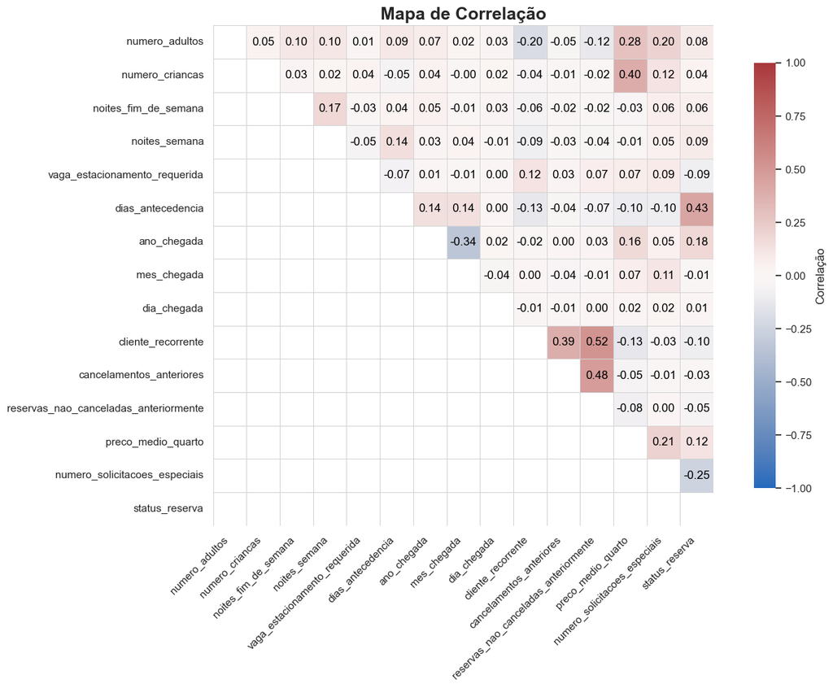

```python
correlacao(df)
```

### 5.2. Técnica de variância

```python
df.var(numeric_only=True)
```

```
numero_adultos                              0.253987
numero_criancas                             0.148761
noites_fim_de_semana                        0.759846
noites_semana                               1.988416
vaga_estacionamento_requerida               0.029823
dias_antecedencia                        7390.704119
ano_chegada                                 0.145180
mes_chegada                                 9.372181
dia_chegada                                76.487283
cliente_recorrente                          0.022022
cancelamentos_anteriores                    0.132155
reservas_nao_canceladas_anteriormente       2.708701
preco_medio_quarto                       1072.364026
numero_solicitacoes_especiais               0.612752
status_reserva                              0.222063
dtype: float64
```

### 5.3. Técnica de information value (IV)

- **Information Value (IV):**
  - **Exclusão:** Esta variável está vazando informação sobre o resultado (data leakage). Um ID nunca deveria ter poder preditivo. Isso pode acontecer se, por exemplo, os ID's foram criados em sequência e a taxa de cancelamento mudou ao longo do tempo.
  - **Investigação:** dias_antecedencia. Um IV tão alto também é suspeito, mas, diferente do ID, a antecedência da reserva é uma variável que esperamos que seja muito preditiva devido a alta variância e uma correlação de pearson de 0.43. Um valor tão alto de IV pode indicar que existe uma relação quase perfeita para certos intervalos (ex.: "reservas com mais de 300 dias de antecedência sempre são canceladas"). Após a análise do gráfico de densidade e box plot chegamos a conclusão que essa variável é, de fato, muito poderosa devido aos seguintes fatores:
    - Curva Azul (Não Cancelaram - status_reserva = 0): Possui um pico muito alto e agudo próximo do zero. Isso significa que a grande maioria das reservas que NÃO são canceladas é feita com pouquíssima antecedência (reservas de "última hora").
    - Curva Verde (Cancelaram - status_reserva = 1): É muito mais achatada e espalhada. O pico dela está bem mais para a direita. Isso mostra que as reservas canceladas tendem a ser feitas com muito mais antecedência, e o comportamento é mais variado.
  - **Manter (a princípio):** Embora tenham baixo poder preditivo individual, modelos mais complexos podem ser capazes de extrair valor da combinação de muitas variáveis fracas. Para um modelo mais simples, podemos optar por excluir as variáveis com IV "Muito baixo" (< 0.02) para simplificar o modelo. Contudo, deixaremos para o futuro (dependendo do modelo escolhido).

```python
iv = calculate_iv(df, target='status_reserva')
iv
```

|  | variavel | IV | tipo | classificacao_IV |
| --- | --- | --- | --- | --- |
| 0 | id_reserva | 1.216070 | categórica | Muito alto / suspeito |
| 1 | dias_antecedencia | 0.977736 | numérica | Muito alto / suspeito |
| 2 | numero_solicitacoes_especiais | 0.294132 | numérica | Médio |
| 3 | preco_medio_quarto | 0.168122 | numérica | Médio |
| 4 | mes_chegada | 0.144626 | numérica | Médio |
| 5 | segmento_mercado | 0.104673 | categórica | Médio |
| 6 | ano_chegada | 0.037039 | numérica | Baixo |
| 7 | tipo_plano_refeicao | 0.033497 | categórica | Baixo |
| 8 | noites_semana | 0.032293 | numérica | Baixo |
| 9 | numero_adultos | 0.031945 | numérica | Baixo |
| 10 | noites_fim_de_semana | 0.011008 | numérica | Muito baixo |
| 11 | reservas_nao_canceladas_anteriormente | 0.007573 | numérica | Muito baixo |
| 12 | tipo_quarto_reservado | 0.006028 | categórica | Muito baixo |
| 13 | dia_chegada | 0.003190 | numérica | Muito baixo |
| 14 | numero_criancas | 0.001821 | numérica | Muito baixo |
| 15 | cancelamentos_anteriores | 0.001332 | numérica | Muito baixo |
| 16 | vaga_estacionamento_requerida | 0.000553 | numérica | Muito baixo |
| 17 | cliente_recorrente | 0.000484 | numérica | Muito baixo |

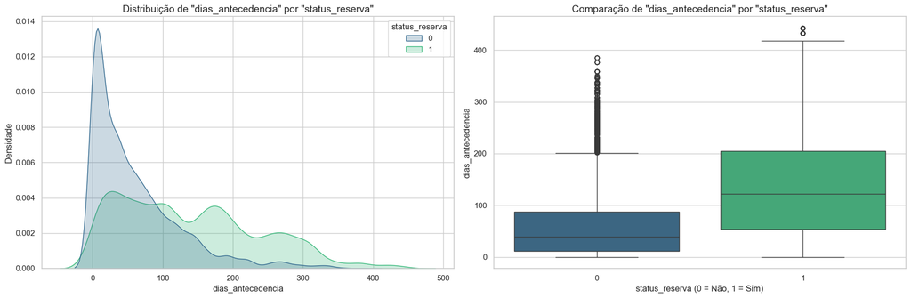

```python
plotar_analise_numerica_vs_target(df, 'dias_antecedencia', 'status_reserva')
```

### 6. Análise descritiva unidimensional

### 7. Transformação de variáveis booleanas

### 8. Tratamento de valores nulos e outliers

### 9. Engenharia de features

**1. numero_adultos (IV = Baixo):**

- As reservas são majoritariamente para dois adultos (72,7%), indicando um forte perfil de casais, seguidas por viajantes individuais (20,7%). Juntas, estas duas categorias representam mais de 93% das estadias, tornando grupos maiores uma clara exceção no conjunto de dados.
- Como etapa de pré-processamento, as reservas para 4 adultos foram segregadas do dataset principal. Esses 15 registros não representativo e sua baixa frequência poderiam introduzir **ruído** nos resultados do modelo. As linhas removidas foram armazenadas no DataFrame df_chave.

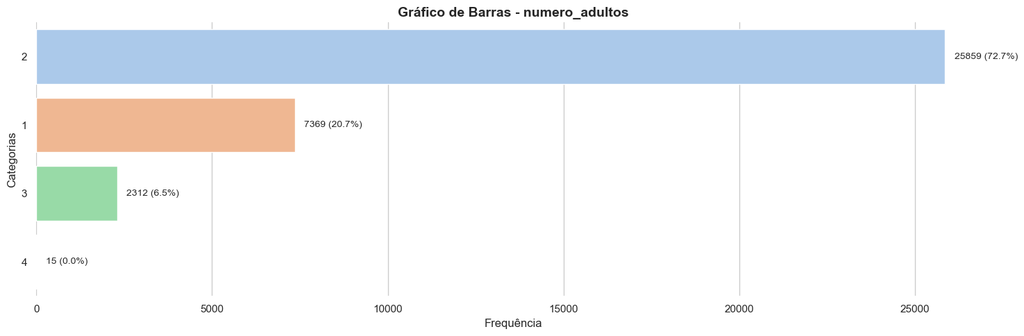

```python
barras(df['numero_adultos'])
```

```python
df_chave = df[df['numero_adultos'] == 4]
```

```python
df = df[df['numero_adultos'] != 4]
```

**2. numero_criancas (IV = Muito baixo):**

- A esmagadora maioria das reservas (92,9%) é feita sem crianças, definindo o perfil padrão do hóspede como adulto. Viagens em família com um ou dois filhos são um nicho de mercado, correspondendo a menos de 8% do total.
- O mesmo critério de limpeza foi aplicado a esta variável, resultando na remoção de 15 registros. As categorias com 3, 9 e 10 crianças foram segregadas por não possuírem representatividade estatística, ou seja, são **ruídos**, evitando que o modelo tente aprender com casos excepcionais ou possíveis erros de entrada.
- Mais de 97% das observações estão nas categorias "0 e 1 criança", que por terem um WoE próximo de zero, não ajudam a prever o evento-alvo. O único sinal preditivo relevante (risco elevado) está no grupo "2 crianças", porém ele representa uma minoria muito pequena dos dados (2.6%). Por isso, o IV da variável é muito baixo, pois o forte poder preditivo de uma minoria não tem peso suficiente para dar relevância à variável como um todo. Indicação é **excluir** essa variável do modelo.

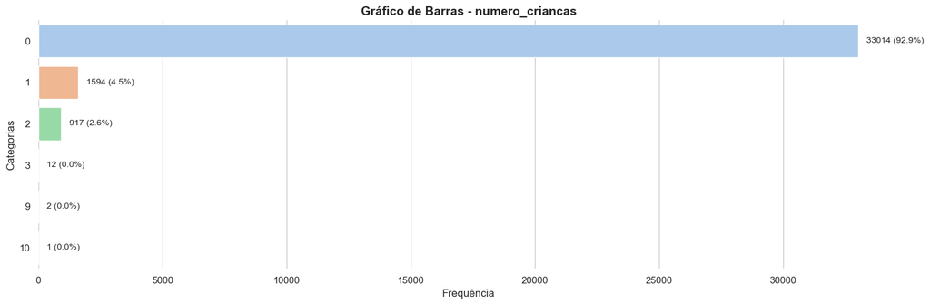

```python
barras(df['numero_criancas'])
```

```python
df_chave = df[df['numero_criancas'].isin([3, 9, 10])]
```

```python
df = df[~df['numero_criancas'].isin([3, 9, 10])]
```

```python
analise_woe = analisar_variavel_com_woe(df, variavel='numero_criancas', target='status_reserva', bins=10)
analise_woe
```

|  | numero_criancas | WoE | representatividade | total | count_0 | count_1 | perc_1_na_categoria |
| --- | --- | --- | --- | --- | --- | --- | --- |
| 0 | 2 | -0.496130 | 0.025813 | 917 | 504 | 413 | 0.450382 |
| 1 | 1 | -0.026481 | 0.044870 | 1594 | 1054 | 540 | 0.338770 |
| 2 | 0 | 0.016026 | 0.929317 | 33014 | 22142 | 10872 | 0.329315 |

**5. tipo_plano_refeicao (IV = Baixo):**

- O perfil de consumo de refeições é dominado pelo Meal Plan 1, que representa o principal produto do hotel. Existe um público secundário relevante que opta pela flexibilidade de não ter um plano de refeições. O Meal Plan 2 serve a um nicho menor, enquanto as outras opções são inexpressivas.
- Uma categoria com uma única amostra é apenas **ruído** estatístico e não ajuda o modelo a aprender. Removê-la é a prática mais correta para garantir a máxima limpeza dos dados, ainda que o impacto na performance seja insignificante.

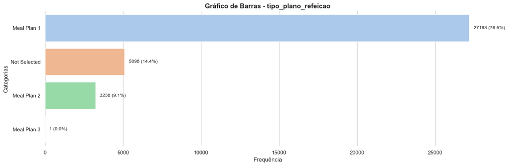

```python
barras(df['tipo_plano_refeicao'])
```

```python
df_chave = df[df['tipo_plano_refeicao'] == 'Meal Plan 3']
```

```python
df = df[df['tipo_plano_refeicao'] != 'Meal Plan 3']
```

**6. vaga_estacionamento_requerida (IV = Muito baixo):**

- A necessidade de estacionamento é muito baixa entre os hóspedes deste hotel. Quase 97% dos clientes não solicitam este serviço, o que pode indicar que a maioria chega ao local utilizando outros meios de transporte, como táxis, aplicativos de transporte, translados ou transporte público.
- A variável identifica um pequeno grupo (3% da base) de clientes de baixíssimo risco: aqueles que pedem vaga de estacionamento (WoE = 1.45). O IV geral é baixo porque a esmagadora maioria dos clientes (97%) está no grupo 'sem vaga', que se comporta de forma neutra e não oferece poder preditivo. Apesar do baixo IV, a variável **deve ser mantida** no modelo, pois ela captura um nicho de clientes com um comportamento muito distinto e previsível.

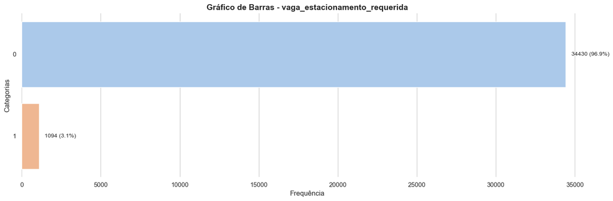

```python
barras(df['vaga_estacionamento_requerida'])
```

```python
analise_woe = analisar_variavel_com_woe(df, variavel='vaga_estacionamento_requerida', target='status_reserva', bins=10)
analise_woe
```

|  | vaga_estacionamento_requerida | WoE | representatividade | total | count_0 | count_1 | perc_1_na_categoria |
| --- | --- | --- | --- | --- | --- | --- | --- |
| 0 | 0 | -0.032541 | 0.969204 | 34430 | 22720 | 11710 | 0.340110 |
| 1 | 1 | 1.456010 | 0.030796 | 1094 | 980 | 114 | 0.104205 |

**7. tipo_quarto_reservado (IV = Muito baixo):**

- A demanda por quartos no hotel é altamente concentrada em duas categorias principais. O Room_Type 1 é o produto dominante, respondendo por mais de três quartos de todas as estadias. O Room_Type 4 serve como uma alternativa secundária relevante. Juntos, eles compõem 94,9% de todas as reservas, indicando que a estratégia de vendas e a maior parte da receita de acomodação do hotel giram em torno desses dois tipos de quarto.
- Categorias com pouquíssimas amostras, como Room_Type 3 e Room_Type 7, são consideradas **ruído** estatístico e não oferecem padrões confiáveis para o modelo aprender. Removê-las melhora a estabilidade e foca o aprendizado do modelo nas categorias que realmente representam o negócio.
- O sinal preditivo mais forte e confiável que vimos é o do Room_Type 6 (alto risco). Os outros sinais são ou muito fracos (quase nulos para os tipos 1, 2 e 4) ou instáveis (potencialmente o do tipo 5). Portanto, a única informação realmente valiosa que podemos extrair com segurança é a identificação do grupo de alto risco. Indicação é **excluir** essa variável do modelo.

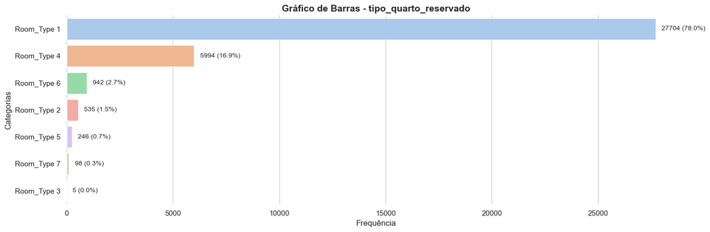

```python
barras(df['tipo_quarto_reservado'])
```

```python
df_chave = df[df['tipo_quarto_reservado'].isin(['Room_Type 3', 'Room_Type 7'])]
```

```python
df = df[~df['tipo_quarto_reservado'].isin(['Room_Type 3', 'Room_Type 7'])]
```

```python
analise_woe = analisar_variavel_com_woe(df, variavel='tipo_quarto_reservado', target='status_reserva', bins=10)
analise_woe
```

|  | tipo_quarto_reservado | WoE | representatividade | total | count_0 | count_1 | perc_1_na_categoria |
| --- | --- | --- | --- | --- | --- | --- | --- |
| 0 | Room_Type 6 | -0.417018 | 0.026594 | 942 | 536 | 406 | 0.430998 |
| 1 | Room_Type 4 | -0.054498 | 0.169222 | 5994 | 3925 | 2069 | 0.345179 |
| 2 | Room_Type 2 | -0.048949 | 0.015104 | 535 | 351 | 184 | 0.343925 |
| 3 | Room_Type 1 | 0.026364 | 0.782135 | 27704 | 18641 | 9063 | 0.327137 |
| 4 | Room_Type 5 | 0.187590 | 0.006945 | 246 | 174 | 72 | 0.292683 |

**8. dias_antecedencia (IV = Muito forte):**

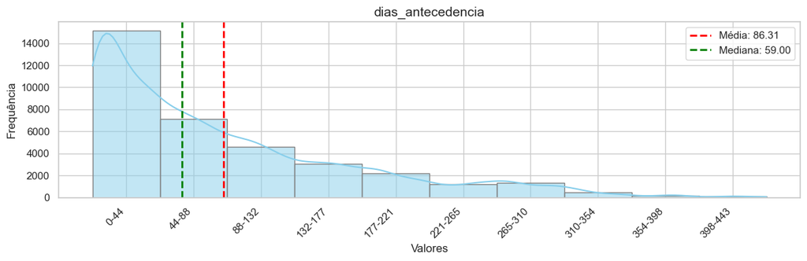

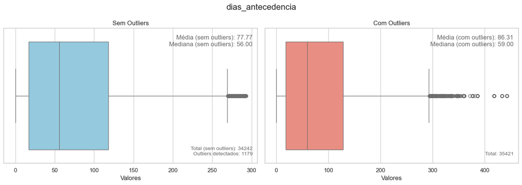

```python
histograma(df['dias_antecedencia'])
boxplot(df['dias_antecedencia'])
```

```python
df = aplicar_winsorizacao(df, ['dias_antecedencia'])
```

**9.10.11. ano (IV = Baixo)/mes (IV = Médio)/dia_chegada (IV = Muito baixo):**

- O conjunto de dados reflete primariamente a atividade do hotel em 2018. Dentro desse período, há uma sazonalidade clara, com um aumento no número de chegadas durante o segundo semestre, especialmente entre maio e outubro. No entanto, dentro de qualquer mês, os hóspedes não têm preferência por um dia específico para chegar, distribuindo suas chegadas de forma uniforme ao longo do mês.
- A variável 'dia_chegada' representa o dia do mês e possui uma distribuição uniforme, sem uma concentração de dados específica. O IV é muito baixo porque provavelmente não existe uma relação de negócio real entre o dia específico do mês e a chance de cancelamento; a variável é não informativa. Indicação é **excluir** essa variável do modelo.

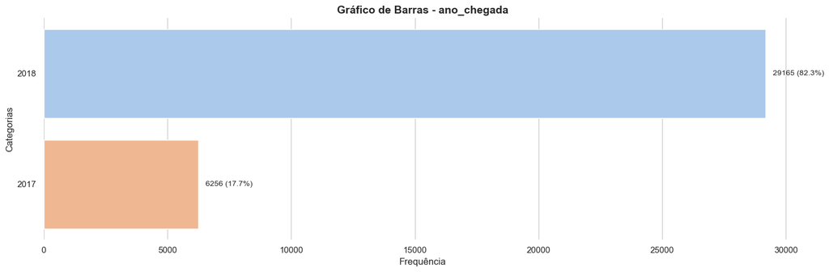

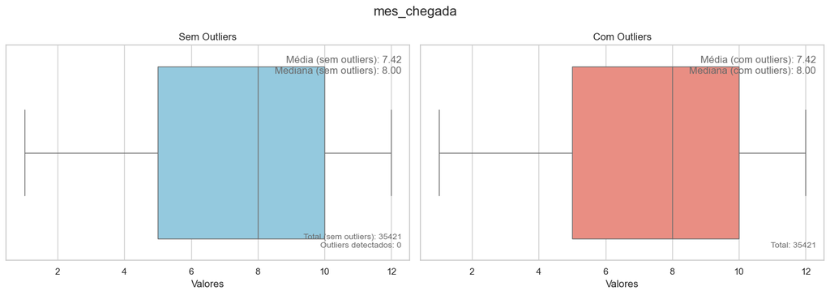

```python
barras(df['ano_chegada'])
boxplot(df['mes_chegada'])
```

**12. segmento_mercado (IV = Médio):**

- A estratégia de aquisição de clientes do hotel é fortemente baseada nos canais Online e Offline, que juntos trazem mais de 93% de todas as reservas. As plataformas digitais são a força motriz, respondendo por quase dois terços do negócio. O canal corporativo funciona como um nicho de mercado complementar importante, enquanto os demais segmentos são residuais.
- As categorias Aviation e Complementary somam menos de 0.5% dos dados e não possuem representatividade estatística para o modelo aprender um padrão confiável, ou seja, **são ruídos**. Removê-las é uma boa prática que simplifica a análise e foca o aprendizado do modelo nos segmentos que realmente definem o negócio (Online, Offline e Corporate).

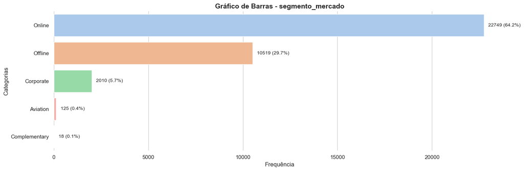

```python
barras(df['segmento_mercado'])
```

```python
df_chave = df[df['segmento_mercado'].isin(['Aviation', 'Complementary'])]
```

```python
df = df[~df['segmento_mercado'].isin(['Aviation', 'Complementary'])]
```

**16. preco_medio_quarto (IV = Médio):**

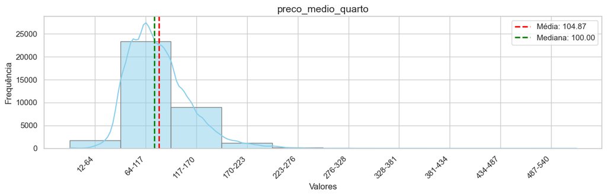

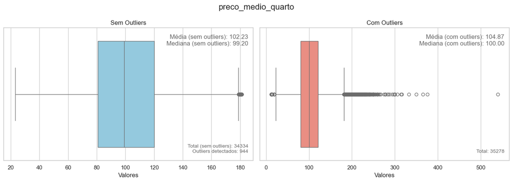

```python
histograma(df['preco_medio_quarto'])
boxplot(df['preco_medio_quarto'])
```

```python
df = aplicar_winsorizacao(df, ['preco_medio_quarto'])
```

**17. numero_solicitacoes_especiais (IV = Médio):**

- Diferente de outras variáveis com comportamento muito concentrado em um único valor, a numero_solicitacoes_especiais mostra uma divisão mais equilibrada. Enquanto a maioria dos clientes não faz pedidos, existe um grupo muito grande e engajado (mais de 43%) que faz de uma a duas solicitações. Isso torna esta variável potencialmente muito importante para um modelo preditivo, pois ela captura um nível de engajamento e especificidade do cliente que outras variáveis não mostram. Um cliente que faz solicitações pode ter um perfil de comprometimento diferente de um que não faz.
- Com um número muito baixo de registros (63 e 8, respectivamente), elas não possuem representatividade estatística para o modelo aprender um padrão confiável. Isolá-las simplifica a variável e reduz o ruído, focando o aprendizado do modelo nas faixas de comportamento mais comuns (0 a 3 solicitações).

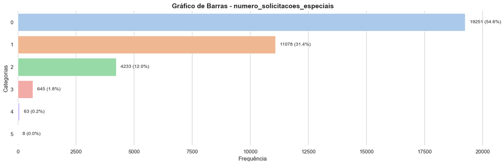

```python
barras(df['numero_solicitacoes_especiais'])
```

```python
df_chave = df[df['numero_solicitacoes_especiais'].isin([4, 5])]
```

```python
df = df[~df['numero_solicitacoes_especiais'].isin([4, 5])]
```

**18. status_reserva:**

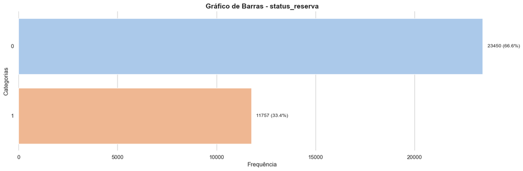

```python
barras(df['status_reserva'])
```

**19. total_noites (IV = Baixo):**

```python
df['total_noites'] = df['noites_fim_de_semana'] + df['noites_semana']
```

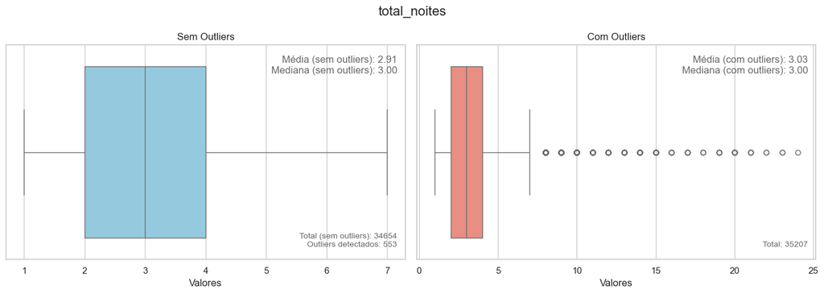

```python
boxplot(df['total_noites'])
```

### 10. Resumo

A análise aprofundada dos dados de reserva do hotel revela um desafio de negócio significativo, visto que aproximadamente uma em cada três reservas é eventualmente cancelada. Essa alta taxa justifica uma investigação sobre o perfil dos clientes, permitindo diferenciar claramente os hóspedes com maior e menor probabilidade de confirmar sua estadia e, assim, informar estratégias comerciais mais eficazes.

O perfil do cliente com alto risco de cancelamento é notavelmente claro e dominado por uma característica principal: o planejamento com extrema antecedência. Quanto maior o intervalo entre a data da reserva e a do check-in, maior a probabilidade de um cancelamento. Este comportamento é frequentemente observado em clientes de primeira viagem, que compõem a maioria das reservas, e também está associado a determinados tipos de quarto que demonstram uma tendência superior à média de cancelamento.

De forma geral, o retrato do cliente típico do hotel é o de um novo hóspede, geralmente um casal viajando sem crianças, que utiliza canais de reserva online. Este cliente padrão opta por estadias curtas, de uma a três noites, e tende a viajar durante a alta temporada do hotel, que se concentra no segundo semestre, entre os meses de maio e outubro.

A compreensão desses distintos perfis de cliente é estratégica. Com este conhecimento, o hotel pode desenvolver ações direcionadas, como políticas de tarifas diferenciadas para reservas feitas com muita antecedência ou a criação de programas de fidelidade para incentivar o retorno de hóspedes, que representam o ativo mais valioso e previsível do negócio.

❌

1. **colunas 0 e 1:**
   - vaga_estacionamento_requerida ✅
   - cliente_recorrente ❌
   - cancelamentos_anteriores ❌
   - reservas_nao_canceladas_anteriormente ❌
   - status_reserva ✅
2. **colunas categóricas:**
   - tipo_plano_refeicao ✅
   - tipo_quarto_reservado ✅
   - segmento_mercado ✅
3. **colunas contínuas:**
   - ano_chegada ✅
   - id_reserva ❌
   - numero_adultos ✅
   - numero_criancas ✅
   - noites_fim_de_semana ❌
   - noites_semana ❌
   - dias_antecedencia ✅
   - mes_chegada ✅
   - dia_chegada ❌
   - preco_medio_quarto ✅
   - numero_solicitacoes_especiais ✅
   - total_noites ✅

### RETIRE AQUI

```python
# Retirada das variáveis  0 e 1
df = df.drop(['cancelamentos_anteriores', 'reservas_nao_canceladas_anteriormente', 'cliente_recorrente'], axis=1)

# Retirada das variáveis hot-encoding \/
#df = df.drop(['tipo_quarto_reservado'], axis=1)

# Retirada das variáveis contínuas \/
df = df.drop(['id_reserva', 'noites_semana', 'noites_fim_de_semana', 'dia_chegada'], axis=1)
```

### 11. One-Hot Encoding

```python
df = pd.get_dummies(df, columns=['tipo_plano_refeicao', 'segmento_mercado', 'tipo_quarto_reservado'])
```

### 12. Modelo

### 13. Separação das variáveis independentes e dependente

```python
y = df['status_reserva']
x = df.drop(['status_reserva'], axis=1)
```

### 14. Separação treino e teste

```python
#stratify para manter proporção das classes
X_train, X_test, y_train, y_test = train_test_split(x, y, test_size=0.30, random_state=42, stratify=y)
```

### 15. Padronização

```python
# Colunas contínuas para normalizar
colunas_continuas = ['numero_adultos',
                     'numero_criancas',
                     'dias_antecedencia',
                     'mes_chegada',
                     'preco_medio_quarto',
                     'numero_solicitacoes_especiais',
                     'total_noites',
                     'ano_chegada']
```

```python
# Inicializa e aplica MinMaxScaler
scaler = MinMaxScaler()
X_train_cont = scaler.fit_transform(X_train[colunas_continuas])
X_test_cont  = scaler.transform(X_test[colunas_continuas])
```

```python
# Colunas binárias (todas menos as contínuas)
colunas_binarias = X_train.drop(columns=colunas_continuas).columns
```

```python
# Dados binários, sem alteração
X_train_bin = X_train[colunas_binarias].reset_index(drop=True)
X_test_bin  = X_test[colunas_binarias].reset_index(drop=True)
```

```python
# Monta DataFrames com dados normalizados e originais
X_train_cont_df = pd.DataFrame(X_train_cont, columns=colunas_continuas)
X_test_cont_df = pd.DataFrame(X_test_cont, columns=colunas_continuas)
```

```python
# Concatena contínuas e binárias
X_train_final = pd.concat([X_train_cont_df, X_train_bin], axis=1)
X_test_final = pd.concat([X_test_cont_df, X_test_bin], axis=1)
```

```python
# Garantir mesma ordem das colunas no teste como no treino
X_test_final = X_test_final[X_train_final.columns]

X_train = X_train_final
X_test = X_test_final
```

### 16. Balanceamento (se necessário)

### 16.1. Aumentando o número de observações (oversampling)

```python
#smoteenn = SMOTEENN(random_state=42)
```

```python
#X_train, y_train = smoteenn.fit_resample(X_train, y_train)
```

### 16.1. Diminuindo o número de observações (undersampling)

```python
#rus = RandomUnderSampler(random_state=42)
```

```python
#X_train, y_train = rus.fit_resample(X_train, y_train)
```

### 17. Aplicação do modelo

```python
models = []
models.append(('Regressão Logística', LogisticRegression(max_iter=1500, random_state=42)))
models.append(('Árvore de Decisão', DecisionTreeClassifier(random_state=42)))
models.append(('Random Forest', RandomForestClassifier(random_state=42)))
models.append(('Extra Trees', ExtraTreesClassifier(random_state=42)))
models.append(('Gradient Boosting', GradientBoostingClassifier(random_state=42)))
models.append(('XGBoost', XGBClassifier(eval_metric='logloss', random_state=42)))
models.append(('LightGBM', LGBMClassifier(verbosity=-1, random_state=42)))
models.append(('Neural Network (MLP)', MLPClassifier(max_iter=1500, random_state=42)))
```

```python
results = []
names = []
scoring = 'accuracy'

print('Iniciando a validação cruzada para todos os modelos...')
```

```
Iniciando a validação cruzada para todos os modelos...
```

```python
for name, model in models:
    kfold = StratifiedKFold(n_splits=10, shuffle=True, random_state=42)

    # Executa a validação cruzada
    cv_results = cross_val_score(model, X_train, y_train, cv=kfold, scoring=scoring)

    # Armazena os resultados
    results.append(cv_results)
    names.append(name)

    # Imprime a média e o desvio padrão da performance de cada modelo
    mean_score = cv_results.mean()
    std_score = cv_results.std()
    print(f"{name}: Acurácia média de {mean_score*100:.2f}% (Desvio Padrão: {std_score:.4f})")

print('='*60)
print('Validação cruzada concluída com sucesso!')
```

```
Regressão Logística: Acurácia média de 80.39% (Desvio Padrão: 0.0070)
Árvore de Decisão: Acurácia média de 85.74% (Desvio Padrão: 0.0092)
Random Forest: Acurácia média de 88.50% (Desvio Padrão: 0.0071)
Extra Trees: Acurácia média de 87.87% (Desvio Padrão: 0.0063)
Gradient Boosting: Acurácia média de 84.68% (Desvio Padrão: 0.0073)
XGBoost: Acurácia média de 88.41% (Desvio Padrão: 0.0049)
```

[output not shown]

```
LightGBM: Acurácia média de 87.73% (Desvio Padrão: 0.0068)
Neural Network (MLP): Acurácia média de 84.83% (Desvio Padrão: 0.0058)
============================================================
Validação cruzada concluída com sucesso!
```

```python
# 1. Extra Trees
modelo_et = ExtraTreesClassifier(random_state=42)
modelo_et.fit(X_train, y_train)
```

```
ExtraTreesClassifier(random_state=42)
```

```python
# 2. XGBoost
modelo_xg = XGBClassifier(eval_metric='logloss', random_state=42)
modelo_xg.fit(X_train, y_train)
```

```
XGBClassifier(base_score=None, booster=None, callbacks=None,
              colsample_bylevel=None, colsample_bynode=None,
              colsample_bytree=None, device=None, early_stopping_rounds=None,
              enable_categorical=False, eval_metric='logloss',
              feature_types=None, feature_weights=None, gamma=None,
              grow_policy=None, importance_type=None,
              interaction_constraints=None, learning_rate=None, max_bin=None,
              max_cat_threshold=None, max_cat_to_onehot=None,
              max_delta_step=None, max_depth=None, max_leaves=None,
              min_child_weight=None, missing=nan, monotone_constraints=None,
              multi_strategy=None, n_estimators=None, n_jobs=None,
              num_parallel_tree=None, ...)
```

```python
# 3. Random Forest
modelo_rf = RandomForestClassifier(random_state=42)
modelo_rf.fit(X_train, y_train)
```

```
RandomForestClassifier(random_state=42)
```

### 18. Avaliação detalhada, seleção do modelo final e otimização do threshold

```python
gerar_relatorio_classificacao("Extra Trees", modelo_et, X_train, y_train, X_test, y_test, detalhado=False)
gerar_relatorio_classificacao("XGBoost", modelo_xg, X_train, y_train, X_test, y_test, detalhado=False)
gerar_relatorio_classificacao("Random Forest", modelo_rf, X_train, y_train, X_test, y_test, detalhado=False)
```

```
============== Extra Trees (Threshold Padrão) ==============

Treino ----------------------------------------------------
Classe 0 - Precisão: 99%, Recall: 100%
Classe 1 - Precisão: 99%, Recall: 98%
Teste -----------------------------------------------------
Classe 0 - Precisão: 90%, Recall: 93%
Classe 1 - Precisão: 84%, Recall: 80%
============================================================

================ XGBoost (Threshold Padrão) ================

Treino ----------------------------------------------------
Classe 0 - Precisão: 92%, Recall: 95%
Classe 1 - Precisão: 90%, Recall: 84%
Teste -----------------------------------------------------
Classe 0 - Precisão: 90%, Recall: 93%
Classe 1 - Precisão: 85%, Recall: 80%
============================================================

============= Random Forest (Threshold Padrão) =============

Treino ----------------------------------------------------
Classe 0 - Precisão: 99%, Recall: 100%
Classe 1 - Precisão: 99%, Recall: 98%
Teste -----------------------------------------------------
Classe 0 - Precisão: 91%, Recall: 93%
Classe 1 - Precisão: 85%, Recall: 81%
============================================================
```

```python
gerar_relatorio_classificacao("XGBoost", modelo_xg, X_train, y_train, X_test, y_test, threshold=0.37 ,detalhado=False)
```

```
================ XGBoost (Threshold = 0.37) ================

Treino ----------------------------------------------------
Classe 0 - Precisão: 95%, Recall: 92%
Classe 1 - Precisão: 85%, Recall: 90%
Teste -----------------------------------------------------
Classe 0 - Precisão: 92%, Recall: 89%
Classe 1 - Precisão: 80%, Recall: 85%
============================================================
```

```python
def prever_com_threshold(modelo, X, threshold):
    """
    Faz previsões de um modelo de classificação usando um threshold customizado.

    Args:
        modelo: O modelo treinado (ex: XGBoost, RandomForest).
        X: Os dados para fazer a previsão.
        threshold: O ponto de corte (float entre 0 e 1).

    Returns:
        Um array com as previsões (0 ou 1).
    """
    # 1. Obter as probabilidades de cada classe (classe 0 e classe 1)
    probs = modelo.predict_proba(X)

    # 2. Selecionar apenas as probabilidades da classe positiva (classe 1, ou seja, "cancelamento")
    probs_positivas = probs[:, 1]

    # 3. Aplicar o threshold: se a prob. for >= threshold, retorna 1, senão 0
    return (probs_positivas >= threshold).astype(int)
```

```python
# --- 6. Análise Financeira: Cenário Base ---
print("\n" + "="*60)
print("Análise Financeira do Cenário Base (Conjunto de Teste)")
print("="*60)

# Seleciona as linhas do DataFrame original que correspondem ao conjunto de teste
df_test = df.loc[y_test.index]
# Filtra apenas as reservas que foram realmente canceladas
reservas_canceladas_df = df_test[y_test == 1]

# Calcula o valor total de cada reserva cancelada
try:
    valor_perdido_por_reserva = (reservas_canceladas_df['noites_semana'] + reservas_canceladas_df['noites_fim_de_semana']) * reservas_canceladas_df['preco_medio_quarto']
except KeyError:
    print("Aviso: Colunas de noites separadas não encontradas. Tentando usar 'total_noites'...")
    valor_perdido_por_reserva = reservas_canceladas_df['total_noites'] * reservas_canceladas_df['preco_medio_quarto']

perda_financeira_total = valor_perdido_por_reserva.sum()
total_reservas_teste = len(y_test)
total_cancelamentos_teste = len(reservas_canceladas_df)

print(f"Total de reservas no conjunto de teste: {total_reservas_teste}")
print(f"Número de cancelamentos reais no teste: {total_cancelamentos_teste}")
print(f"PERDA FINANCEIRA TOTAL (Cenário Base): R$ {perda_financeira_total:,.2f}")
print("="*60)


# --- 7. Análise Financeira: Cenário Simulado (Estratégia: Cobrança Antecipada) ---

# --- Premissas da Simulação (AJUSTADAS) ---
# Nova hipótese de negócio: A ação é uma cobrança antecipada, sem desconto.
taxa_de_sucesso_da_acao = 0.07 # Nova taxa de conversão de 10%

print("\n" + "="*60)
print(f"Análise Financeira do Cenário Simulado (Taxa de Sucesso: {taxa_de_sucesso_da_acao*100:.0f}%)")
print("="*60)

# Previsões com o modelo otimizado (XGBoost com threshold 0.37)
y_pred_teste_otimizado = prever_com_threshold(modelo_xg, X_test, threshold=0.37)

# Identifica os cancelamentos que o modelo previu corretamente (Verdadeiros Positivos)
verdadeiros_positivos_idx = y_test[(y_test == 1) & (y_pred_teste_otimizado == 1)].index
reservas_corretamente_identificadas = df.loc[verdadeiros_positivos_idx]

# Calcula o valor financeiro dessas reservas que poderiam ser salvas
try:
    valor_recuperavel_por_reserva = (reservas_corretamente_identificadas['noites_semana'] + reservas_corretamente_identificadas['noites_fim_de_semana']) * reservas_corretamente_identificadas['preco_medio_quarto']
except KeyError:
    valor_recuperavel_por_reserva = reservas_corretamente_identificadas['total_noites'] * reservas_corretamente_identificadas['preco_medio_quarto']

valor_total_em_risco_identificado = valor_recuperavel_por_reserva.sum()

# Calcula o ganho financeiro (não há mais "líquido" vs "bruto", pois não há custo)
ganho_financeiro_estimado = valor_total_em_risco_identificado * taxa_de_sucesso_da_acao

# --- LÓGICA CORRIGIDA PARA O CÁLCULO PERCENTUAL ---

# 1. Calcula a RECEITA POTENCIAL TOTAL de TODAS as reservas no conjunto de teste
try:
    valor_total_por_reserva_teste = (df_test['noites_semana'] + df_test['noites_fim_de_semana']) * df_test['preco_medio_quarto']
except KeyError:
    valor_total_por_reserva_teste = df_test['total_noites'] * df_test['preco_medio_quarto']
receita_potencial_total_teste = valor_total_por_reserva_teste.sum()

# 2. Calcula a RECEITA REALIZADA no cenário base
receita_realizada_base = receita_potencial_total_teste - perda_financeira_total

# 3. Calcula o aumento percentual usando o denominador correto
if receita_realizada_base > 0:
    aumento_percentual_receita = (ganho_financeiro_estimado / receita_realizada_base) * 100
else:
    aumento_percentual_receita = 0

# --- Exibição dos Resultados Finais (AJUSTADO) ---
print(f"Cancelamentos que o modelo previu corretamente: {len(verdadeiros_positivos_idx)}")
print(f"Valor total em risco identificado pelo modelo: R$ {valor_total_em_risco_identificado:,.2f}")
print("-" * 30)
print(f"GANHO FINANCEIRO ESTIMADO (Receita Adicional): R$ {ganho_financeiro_estimado:,.2f}")
print(f"Receita Realizada no Cenário Base: R$ {receita_realizada_base:,.2f}")
print(f"\nAUMENTO PERCENTUAL ESTIMADO NA RECEITA (CORRIGIDO): {aumento_percentual_receita:.2f}%")
print("="*60)
```

```
============================================================
Análise Financeira do Cenário Base (Conjunto de Teste)
============================================================
Aviso: Colunas de noites separadas não encontradas. Tentando usar 'total_noites'...
Total de reservas no conjunto de teste: 10563
Número de cancelamentos reais no teste: 3527
PERDA FINANCEIRA TOTAL (Cenário Base): R$ 1,222,972.53
============================================================

============================================================
Análise Financeira do Cenário Simulado (Taxa de Sucesso: 7%)
============================================================
Cancelamentos que o modelo previu corretamente: 3013
Valor total em risco identificado pelo modelo: R$ 1,059,981.08
------------------------------
GANHO FINANCEIRO ESTIMADO (Receita Adicional): R$ 74,198.68
Receita Realizada no Cenário Base: R$ 2,049,805.59

AUMENTO PERCENTUAL ESTIMADO NA RECEITA (CORRIGIDO): 3.62%
============================================================
```